# PM2.5 & Asthma Analysis

Author

Pragya, Shradha, Sania, Anish

Published

April 26, 2026

## Overview

This report analyzes the relationship between PM2.5 air pollution levels and asthma prevalence across U.S. states from 2016–2020. The goal is to explore whether higher air pollution is associated with higher asthma rates.

## Preview Data

```
# A tibble: 6 × 5
  statefips  year  pm25 state asthma_rate
      <dbl> <dbl> <dbl> <chr>       <dbl>
1         1  2016  9.73 AL            9.7
2         1  2017  9.32 AL           10.9
3         1  2018  8.91 AL           10.5
4         1  2019  9.17 AL            9.5
5         1  2020  8.73 AL            9
6         4  2016  7.09 AR            8.5
```

## PM2.5 vs Asthma Relationship

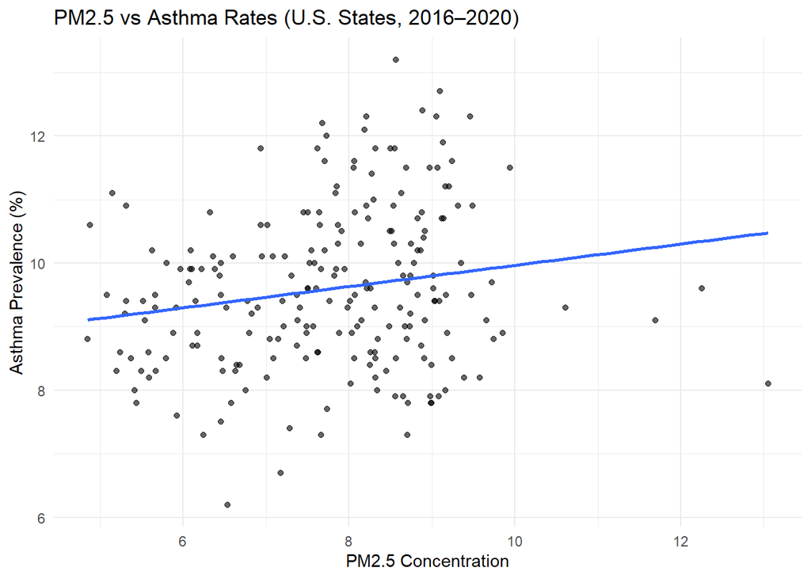

## Trends Over Time

This plot shows how average PM2.5 levels and asthma rates changed over time.

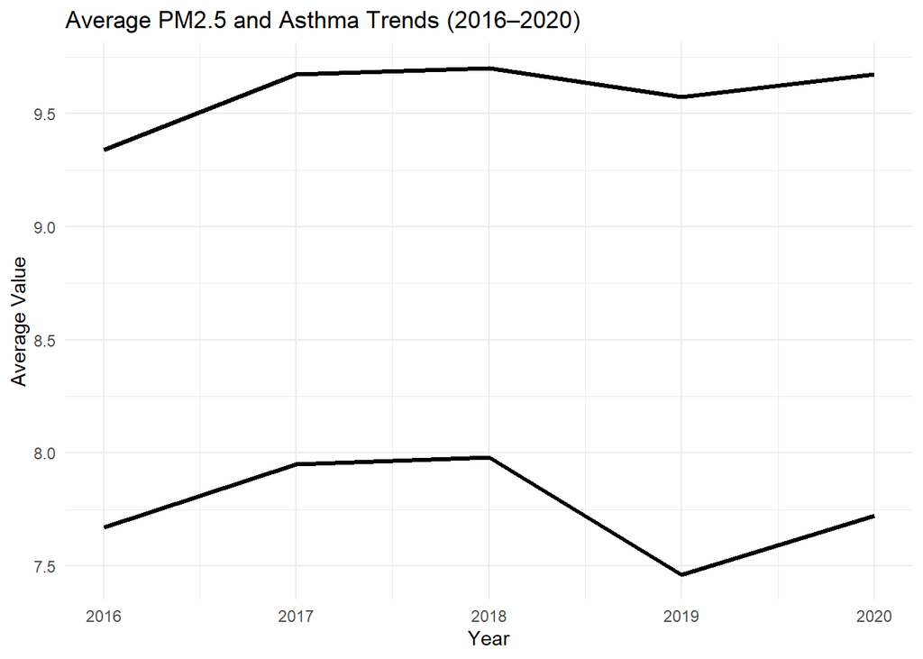

## Correlation

```
[1] 0.1803415
```

## Key Findings

The scatterplot suggests a positive relationship between PM2.5 levels and asthma rates, meaning that states with higher air pollution tend to have higher asthma prevalence. However, the relationship is not perfectly linear, indicating that other factors may also influence asthma outcomes.

The time trend plot shows that both PM2.5 levels and asthma rates fluctuate over time, with no dramatic drop in 2020 despite reduced activity during the COVID-19 pandemic. This suggests that air pollution and asthma are influenced by multiple long-term factors beyond short-term changes.